# Trp53cor1 KO vs WT (Adult)

This file shows the wt-v-ko comparison for Trp53cor1.

Cuff overview:

```
## CuffSet instance with:
##   2 samples
##   26754 genes
##   77524 isoforms
##   0 TSS
##   23066 CDS
##   0 promoters
##   0 splicing
##   19954 relCDS
```

# QC

## Dispersion

Dispersion plot for genes in cuff: (Overdispersion can lead to innacurate quants)

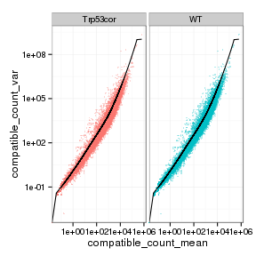

## Cross-replicate variability (fpkmSCVplot)

Differences in CV 2 can result in lower numbers of differentially expressed genes due to a higher degree of variability between replicate fpkm estimates.

Genes:

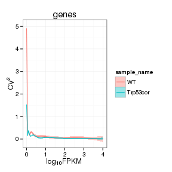

Isoforms:

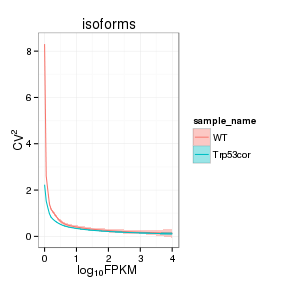

[output not shown]

[output not shown]

## Scatterplot matrix

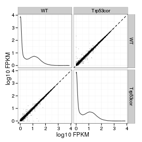

## Distributions

### Boxplots

Boxplot (genes)

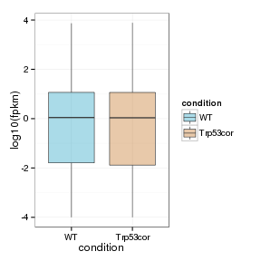

Boxplot (genes, replicates)

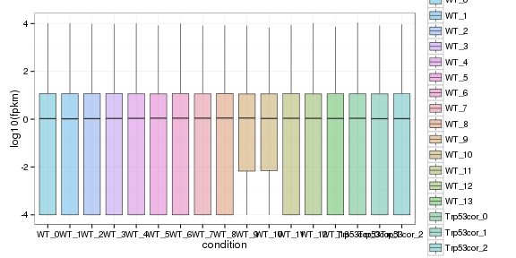

Boxplot (isoforms)

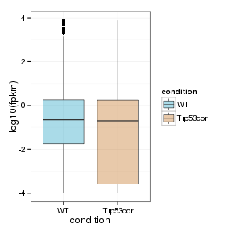

Boxplot (isoforms, replicates)

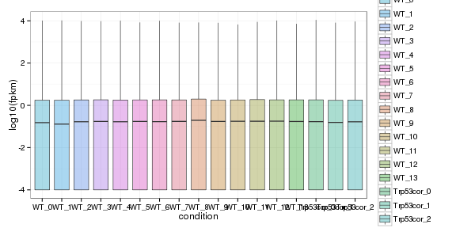

### Density

Density (genes)

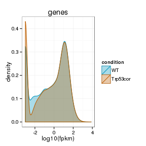

Density (genes, replicates)

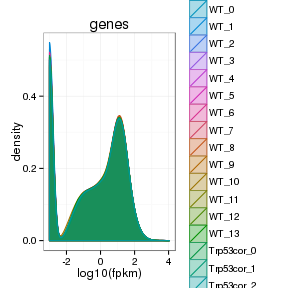

## Clustering

### Replicate Clusters

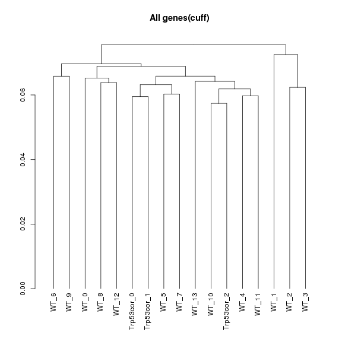

### PCA (genes)

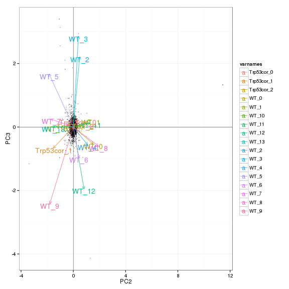

### MDS (genes)

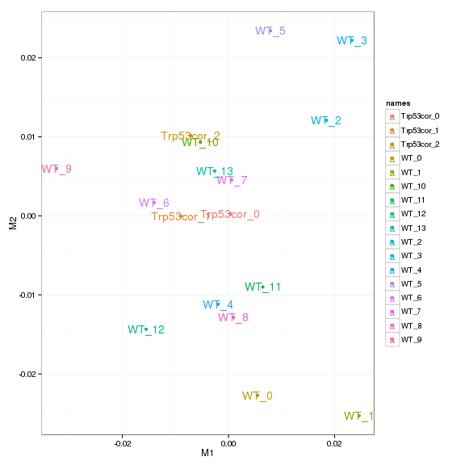

# KO assessment

## Endogenous lncRNA expression

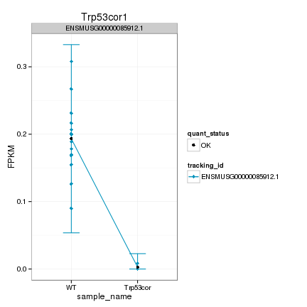

Endogenous expression of Trp53cor1 isoforms:

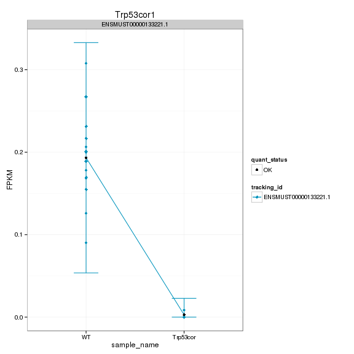

Barplot of gene expression:

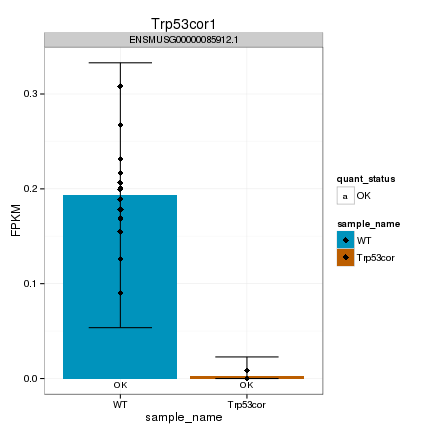

Barplot of isoform expression:

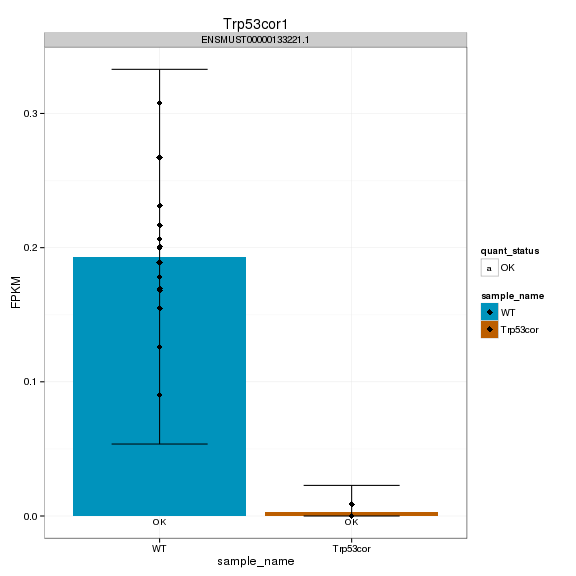

## LacZ expression

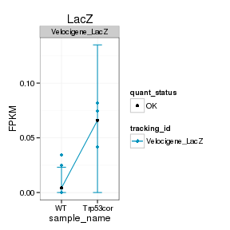

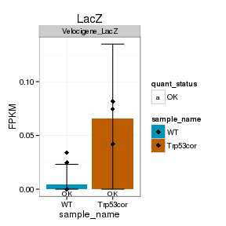

## Digital Genotyping (LacZ vs Endogenous lncRNA and Sex)

Eif2s3y is a y-expressed gene, Xist is an x-expressed gene Expression plot (endogenous linc, lacZ, Y-expressed gene):

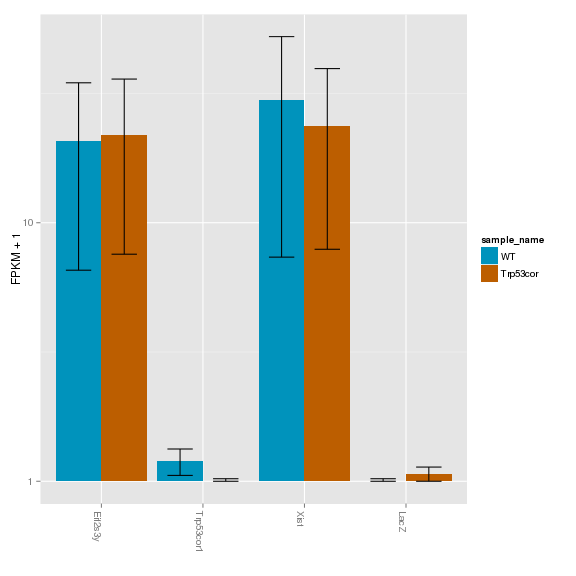

Expression heatmap:

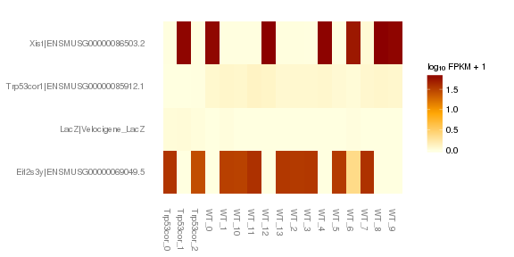

### Track visualization

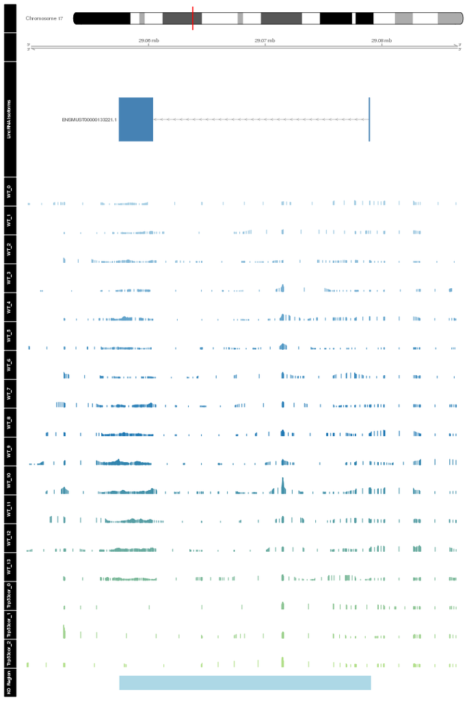

# Differential Analysis

## Differential Genes

There are 69 significantly differentially expressed genes. They are:

|  | geneAnnot$gene_short_name |
| --- | --- |
| 1 | Gabra2 |
| 2 | Arrdc2 |
| 3 | Nes |
| 4 | Epha2 |
| 5 | Khsrp |
| 6 | Odc1 |
| 7 | Tjap1 |
| 8 | Etnppl |
| 9 | Fabp7 |
| 10 | Sgk1 |
| 11 | Adi1 |
| 12 | Serpina3n |
| 13 | Kcnv1 |
| 14 | Cdkn1a |
| 15 | Park2 |
| 16 | Mpc1 |
| 17 | Flywch2 |
| 18 | Mut |
| 19 | Enpp4 |
| 20 | Ppil1 |
| 21 | Cpne5 |
| 22 | Pi16 |
| 23 | Glo1 |
| 24 | Prss41 |
| 25 | Atp6v0c |
| 26 | Spsb3 |
| 27 | Adamts10 |
| 28 | Rps24 |
| 29 | Rps6 |
| 30 | Adamts9 |
| 31 | Gkn3 |
| 32 | A2m |
| 33 | Hddc3 |
| 34 | Tlr13 |
| 35 | Arhgap27 |
| 36 | Rnps1 |
| 37 | Lars2 |
| 38 | 3110052M02Rik |
| 39 | Decr2 |
| 40 | Cramp1l |
| 41 | Gm129 |
| 42 | Akap12 |
| 43 | Itpkb |
| 44 | Lyplal1 |
| 45 | Fmo2 |
| 46 | Rps19 |
| 47 | Maff |
| 48 | Gm9493 |
| 49 | Zfp758 |
| 50 | Acp1 |
| 51 | Hmga1 |
| 52 | Tmem252 |
| 53 | Pla2g4e |
| 54 | Tagap1 |
| 55 | Arntl |
| 56 | Per2 |
| 57 | H2-T22 |
| 58 | Ide |
| 59 | Cox5b |
| 60 | H2-T23 |
| 61 | Zfp760 |
| 62 | H2-Bl |
| 63 | 9030025P20Rik |
| 64 | Hmga1-rs1 |
| 65 | Apold1 |
| 66 | AA465934 |
| 67 | Rpl41 |
| 68 | Gm9825 |
| 69 | Tmem181b-ps |

### Matrix of gene significant differences between conditions

(skip for Brainmap wt-v-ko comparisons)

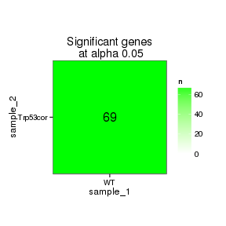

### Significant gene expression differences between conditions

Expression plot (genes):(turned off)

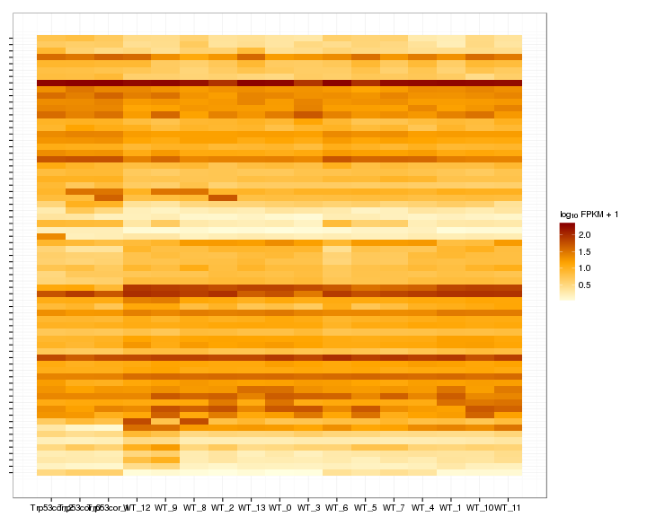

Significant genes with expression >50fpkm (any condition):(turned off)

An individual look at each of the highly expressed significantly differentially regulated genes: (eval=false for first pass)

### Expression-level/significance relationship

[output not shown]

[output not shown]

[output not shown]

FoldChange Heatmap

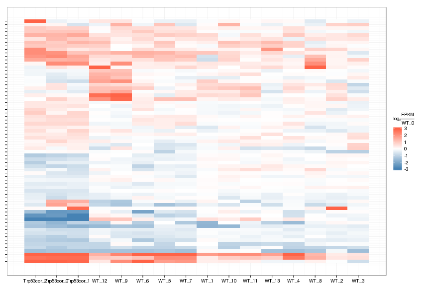

## Differential Splicing

### Differential Isoforms between conditions

Per isoform difference between conditions:

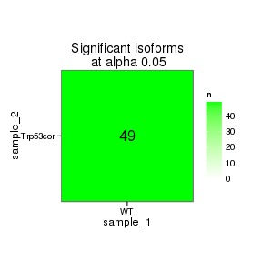

These isoforms are:

|  | isoAnnot$gene_short_name |
| --- | --- |
| 1 | Gabra2 |
| 2 | Rec8 |
| 3 | Klf4 |
| 4 | Nes |
| 5 | Prlr |
| 6 | Epha2 |
| 7 | Khsrp |
| 8 | Etnppl |
| 9 | Fabp7 |
| 10 | Serpina3n |
| 11 | Tfrc |
| 12 | Cdkn1a |
| 13 | Hcfc1r1 |
| 14 | Mut |
| 15 | Ppil1 |
| 16 | Cpne5 |
| 17 | Glo1 |
| 18 | Atp6v0c |
| 19 | Adamts10 |
| 20 | Rps24 |
| 21 | Gng13 |
| 22 | Gkn3 |
| 23 | A2m |
| 24 | Hddc3 |
| 25 | Vps8 |
| 26 | Rnps1 |
| 27 | Lars2 |
| 28 | 3110052M02Rik |
| 29 | Decr2 |
| 30 | Cramp1l |
| 31 | Ano2 |
| 32 | Akap12 |
| 33 | Itpkb |
| 34 | Lyplal1 |
| 35 | Fmo2 |
| 36 | Bcor |
| 37 | Gm9493 |
| 38 | Pla2g4e |
| 39 | Tagap1 |
| 40 | Arntl |
| 41 | Ide |
| 42 | Zfp945 |
| 43 | Zfp760 |
| 44 | Fndc1 |
| 45 | H2-Bl |
| 46 | 9030025P20Rik |
| 47 | Mog |
| 48 | Apold1 |
| 49 | Gm9825 |

Gene-level DE isoform heatmap

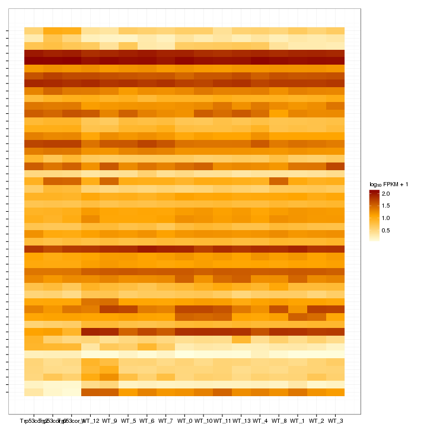

Isoform foldchange heatmap by isoform:

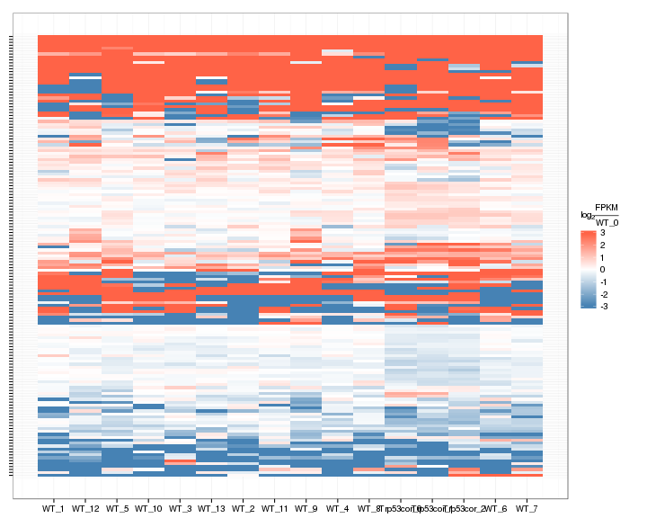